# More mov CV

ABT-MSE Operating model fitting report

Tom Carruthers

January 11, 2019

# 1 Operating model scenario

1: West: h=0.6 to hockey stick 1975+, East: h=0.98 for 1987- to h=0.98 1988+  
A: Best estimates  
I: Younger spawning, High M

# 2 Area definitions

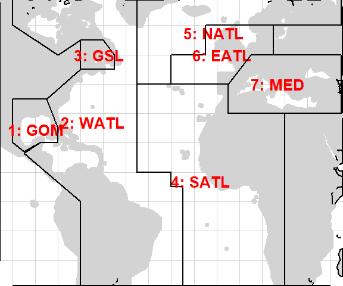

Figure 1. Area definitions for operating model

# 3 Fits to CPUE indices

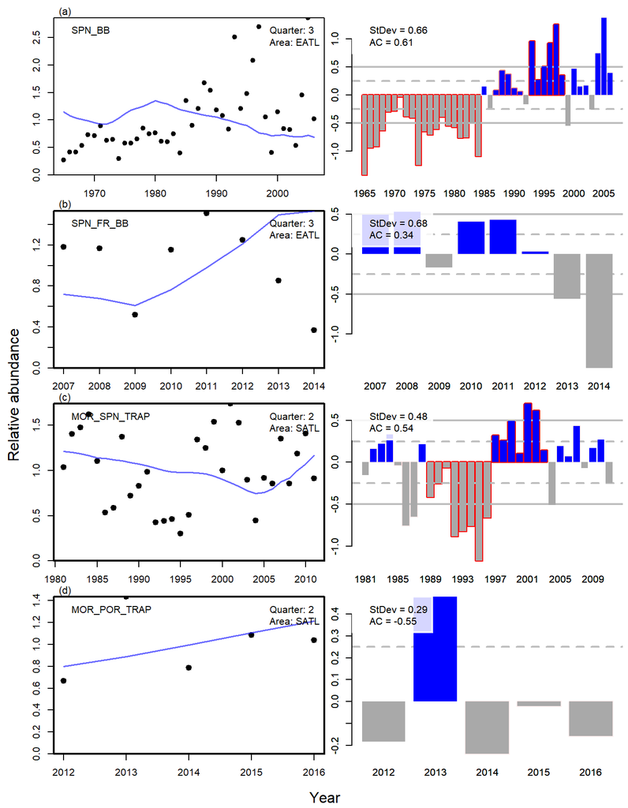

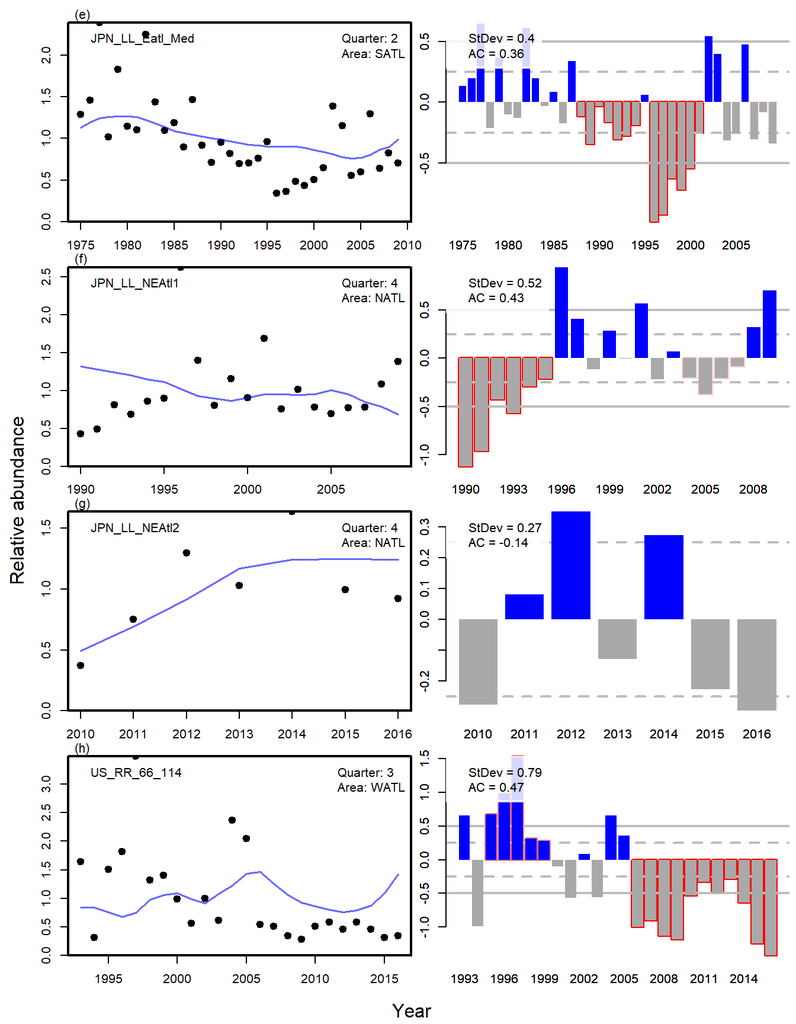

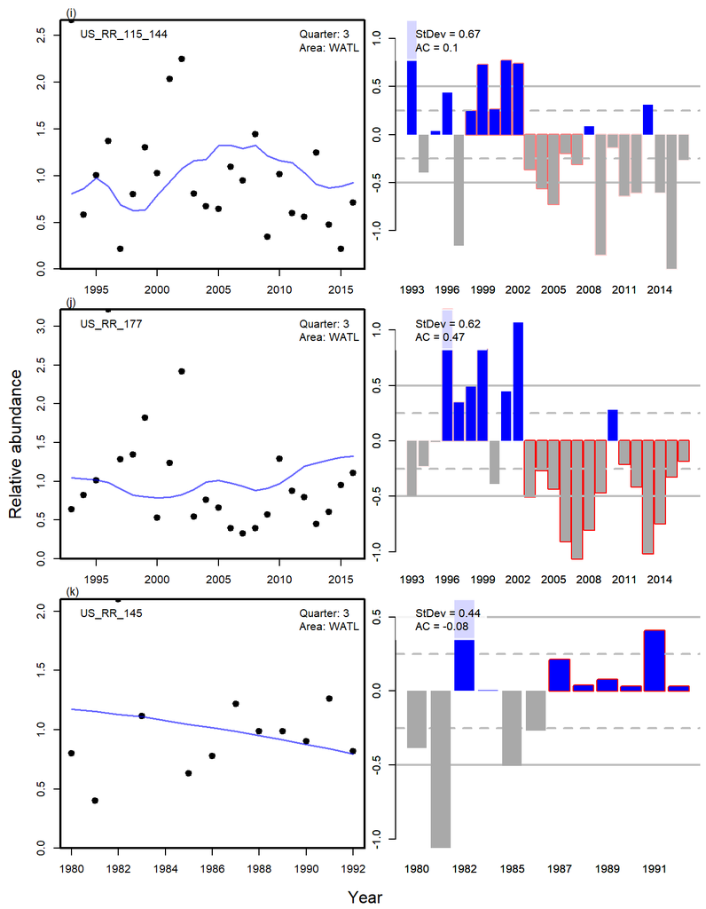

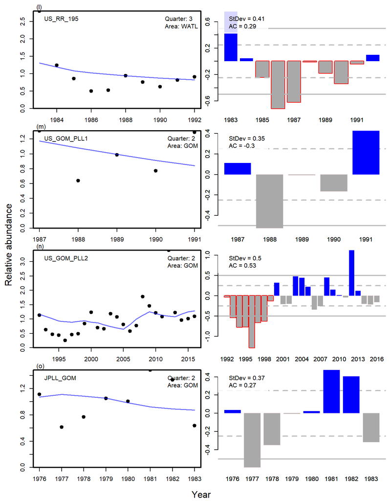

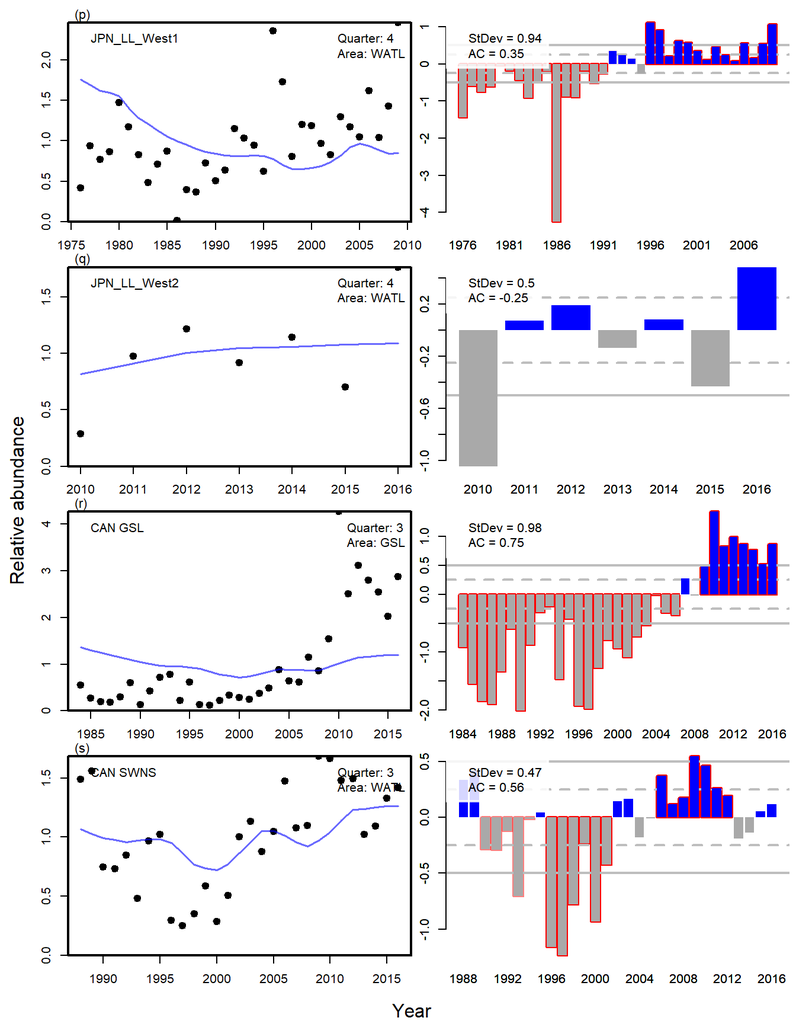

Figure 2. Operating model fits to CPUE indices. Each row corresponds with an index. The left-hand panels show the normalized (log index has mean 0) observed (black dots) and model predicted (blue line) indices. The right-hand panels show the log devitations (the observation model is log-normal) including the residual standard deviation (StDev) and lag-1 autocorrelation in residuals (AC). Runs of positive or negative residuals are highlighted with a red border. The dashed and solid horizontal grey lines are the same on each plot - the scale of y-axis varies among indices for these plots.

# 4 Fits to FI indices

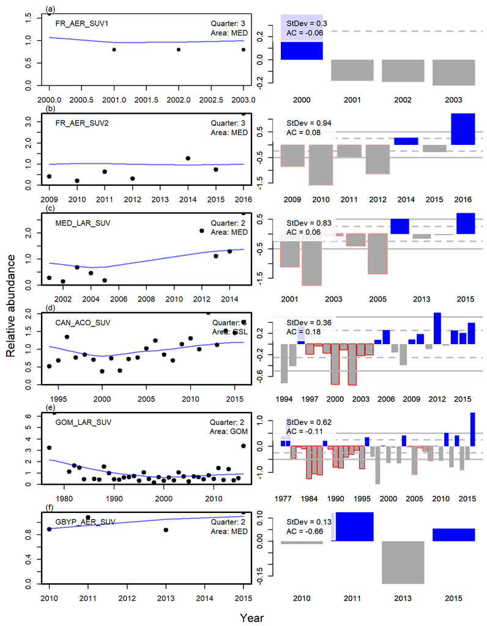

Figure 3. Operating model fits to fishery-independent indices. Each row corresponds with an index. The left-hand panels show the normalized (log index has mean 0) observed (black dots) and model predicted (blue line) indices. The right-hand panels show the log devitations (the observation model is log-normal) including the residual standard deviation (StDev) and lag-1 autocorrelation in residuals (AC). Runs of positive or negative residuals are highlighted with a red border. The dashed and solid horizontal grey lines are the same on each plot - the scale of y-axis varies among indices for these plots.

# 5 Spawning biomass

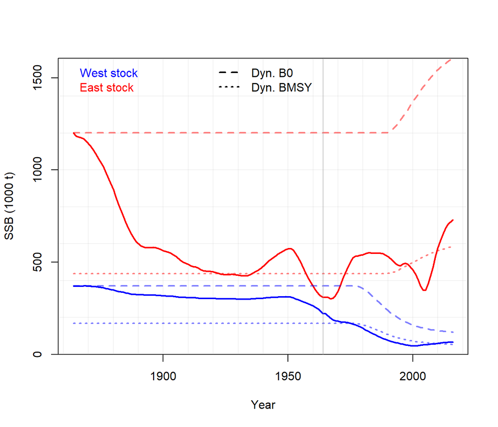

Figure 4a. Historical spawning biomass. Dynamic unfished spawning biomass (Dyn. B0) is calculated using year-specific estimates of recruitment strength assuming that there was zero fishing (ie it lags shifts in productivity). Dynamic BMSY is a fixed fraction of B0 based on the most recent estimates of BMSY relative to unfished.

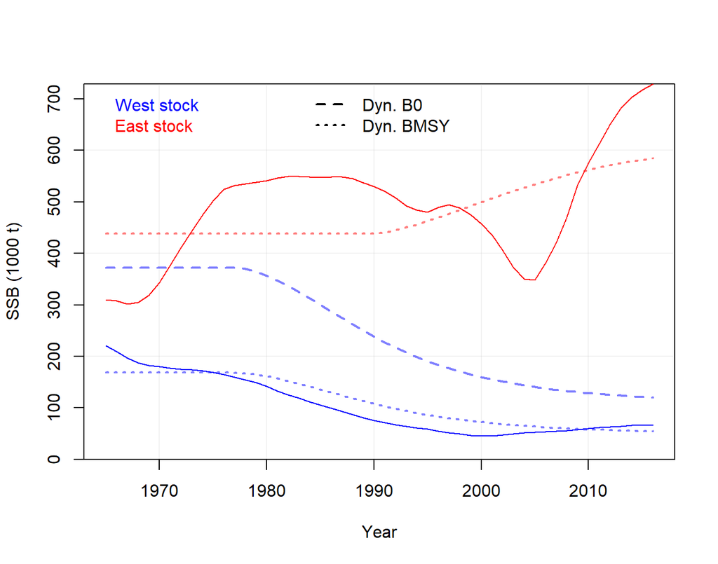

Figure 4b. Recent spawning biomass. Dynamic unfished spawning biomass (Dyn. B0) is calculated using year-specific estimates of recruitment strength assuming that there was zero fishing (ie it lags shifts in productivity). Dynamic BMSY is a fixed fraction of B0 based on the most recent estimates of BMSY relative to unfished.

# 6 Assessment comparison

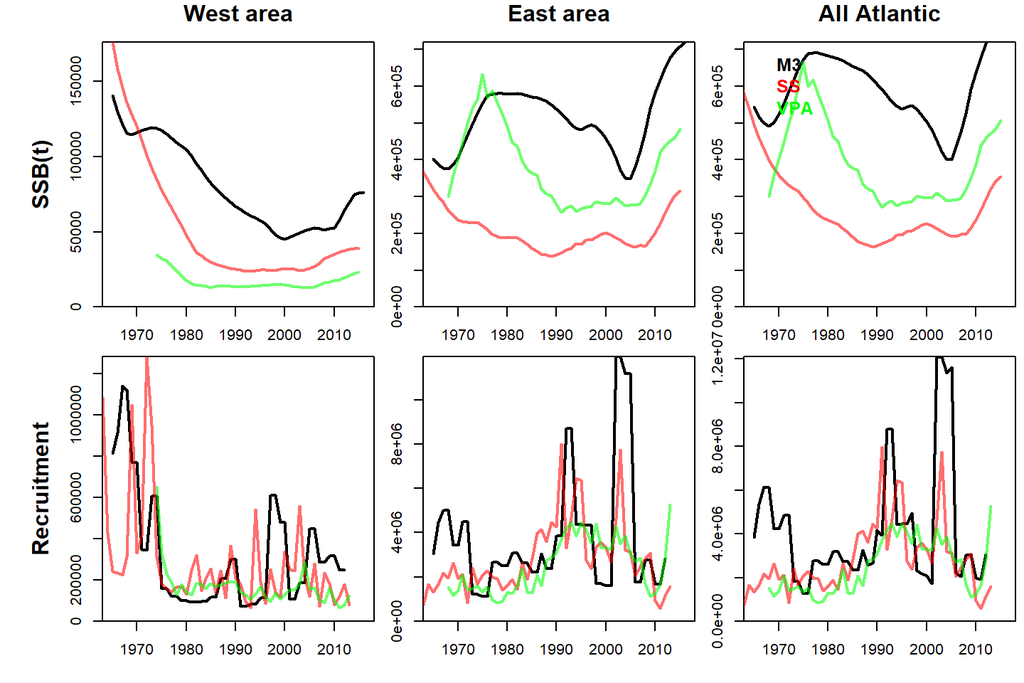

Figure 5. Regional comparisons (45deg W) with 2017 stock assessment. Note that annual estimates from the operating model are calculated from average of the seasonal predictions.

# 7 Stock-recruitment relationships

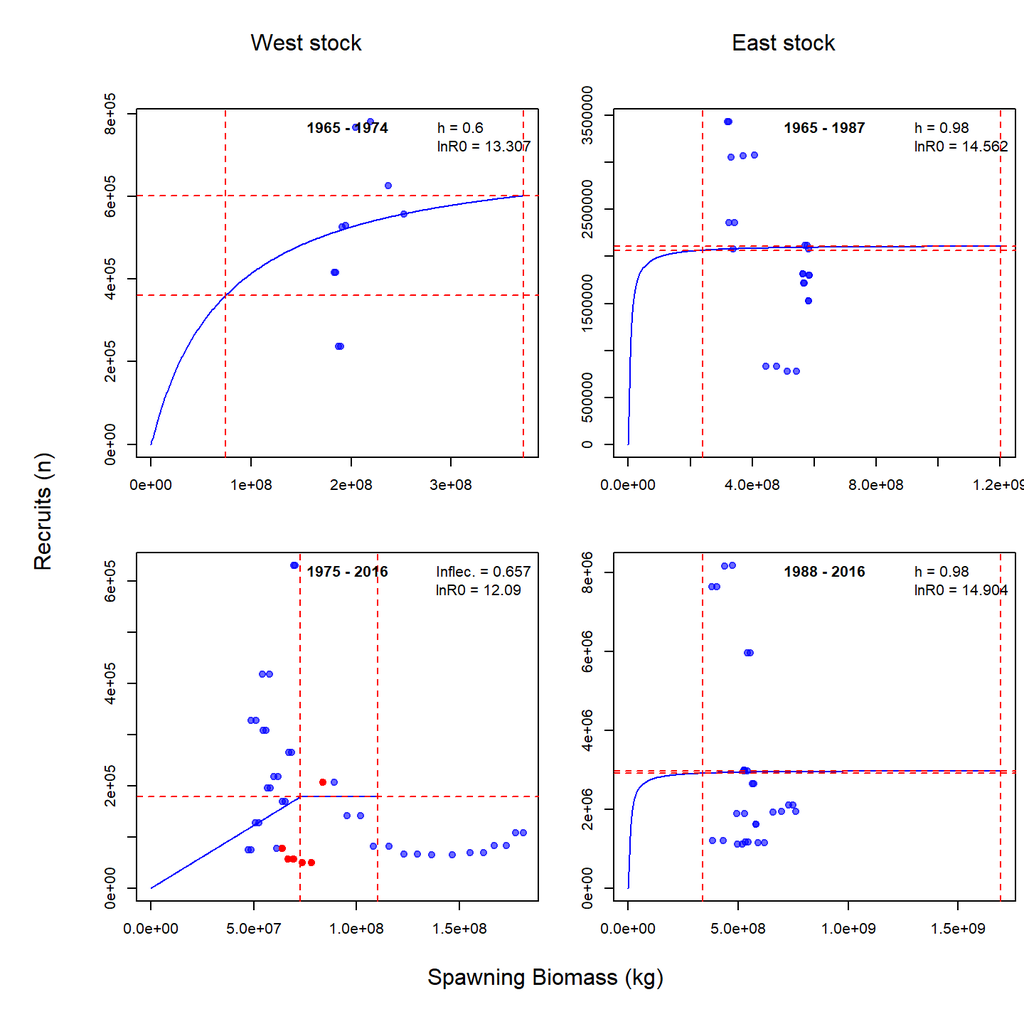

Figure 6. Model predicted spawning stock biomass and recruitment. h is the assumed value of steepness, lnR0 is the log unfished recruitment. In the case of the hockey stick SR model, Inflec. is the biomass position of the inflection (join) point relative to unfished.Hockey-stick stock-recruitment curves define the inflection point as the mean biomass in the range of 1990-1995, and these depicted by red points.

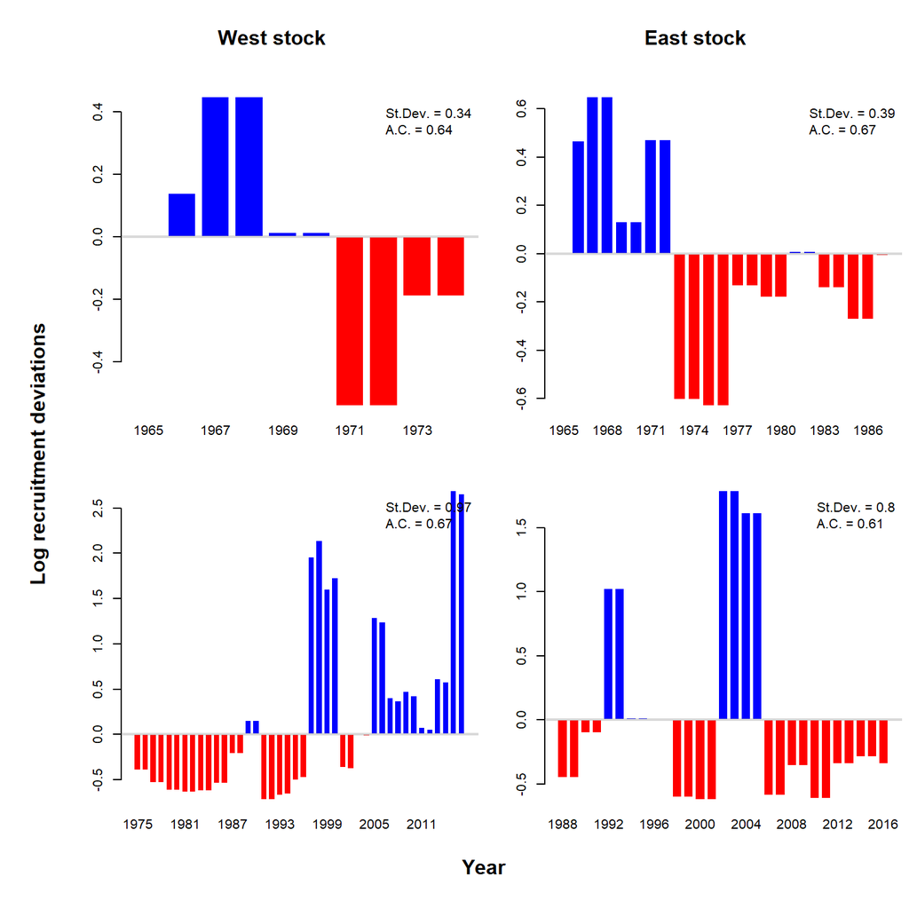

Figure 6. Recruitment deviations (log) for each stock-recruitment curve. Recruitment deviations are modelled for two-year time blocks. Blue bars represent positive deviations where the estimated recruitment is higher than the mean value predicted from the stock-recruitment curve. Red bars represent negative deviations. ‘St.Dev’. and ‘A.C’. refer to the Standard Deviation and lag-1 autocorrelation in recruitmetn deviations.

# 8 MSY reference points

Table 1a. 2016 Reference points by area. MSY and BMSY numbers are in tons. Biomass figures (BMSY, B0) refer to Spawning Stock Biomass. Stock depletion refers to spawning stock biomass relative to ‘dynamic B0’ (a running calculation of unfished stock size accounting for shifts in recruitment). Similarly, BMSY is calculated as a dynamic quantity relating to ‘dynamic B0’.

|  | MSY | BMSY | BMSY_B0 | B_BMSY | Dep |
| --- | --- | --- | --- | --- | --- |
| East area | 53785 | 666840 | 0.367 | 1.075 | 0.458 |
| West area | 3605 | 70115 | 0.409 | 1.131 | 0.505 |

Table 1b. 2016 Reference points by stock. MSY and BMSY numbers are in tons. Biomass figures (BMSY, B0) refer to Spawning Stock Biomass. Fishing rate figures (FMSY, F) are phrased as apical Fs (F on the most selected length class). Stock depletion refers to spawning stock biomass relative to ‘dynamic B0’ (a running calculation of unfished stock size accounting for shifts in recruitment). Similarly BMSY is calculated as a dynamic quantity relating to ‘dynamic B0’.

|  | MSY | FMSY | BMSY | BMSY_B0 | F_FMSY | B_BMSY | Dep |
| --- | --- | --- | --- | --- | --- | --- | --- |
| East stock | 56409 | 0.586 | 680998 | 0.364 | 0.208 | 1.071 | 0.454 |
| West stock | 981 | 0.024 | 55957 | 0.452 | 2.261 | 1.189 | 0.553 |

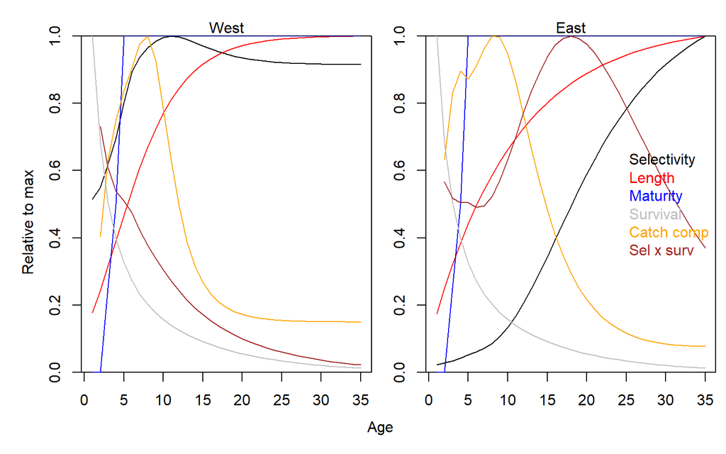

Figure 7. Age-specific quantities determining 2016 MSY reference points. Survival is based on natural mortality only. Catch comp (orange line) is the age composition of all catch at length data (converted to age via an ALK). Sel x surv is the unfished predicted age composition of catches based on 2016 selectivity (black line) and unfished age structure from survival (grey line). Sel x surv (brown line) provides an approximate check of the model approximation of catch composition. The sel x surv should be of higher age (to the right of) the catch comp that is from an exploited population.

# 9 Current F-at-age profile

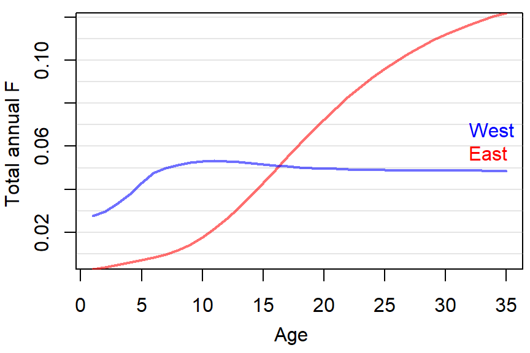

Figure 8. The current profile of F at age summed over all fleets, average weighed (by total contribution to annual F) over seasons and areas.

# 10 Estimated size selectivity

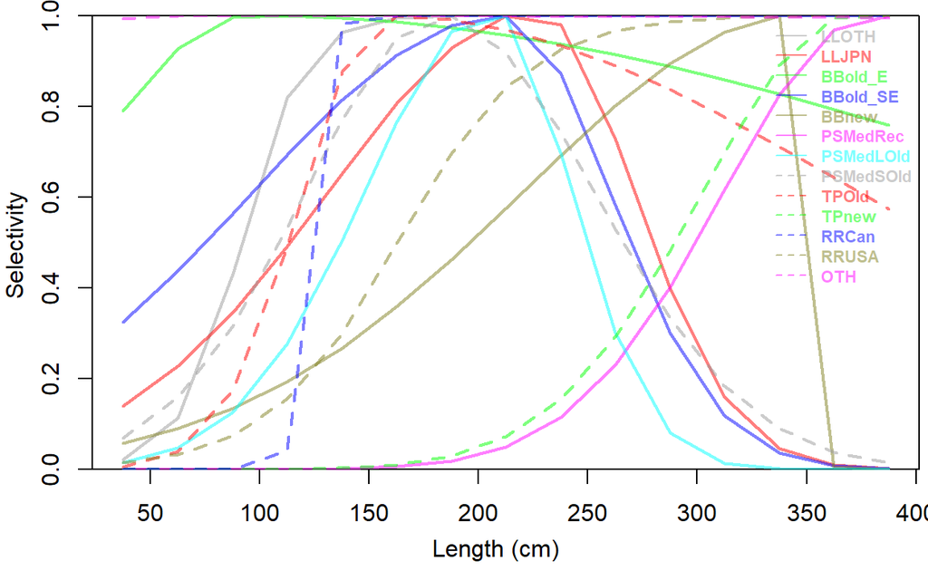

Figure 9. The size selectivity of the various fishing fleets included in the operating model.

# 11 Fit to aggregate catches

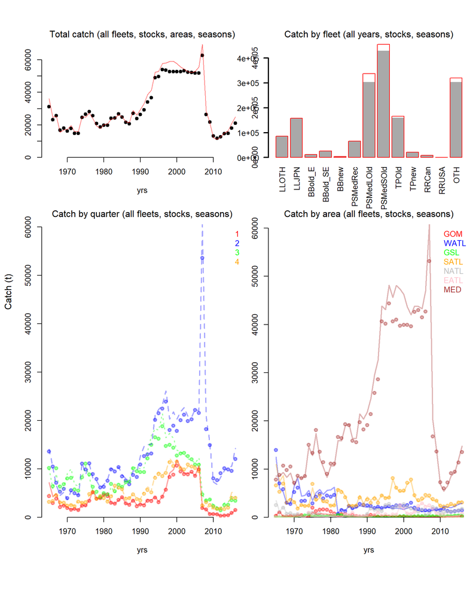

Figure 10. Fit to a observed total catches (tons) aggregated over various axes (lines = predicted, points = observed)

# 12 Fit to length composition

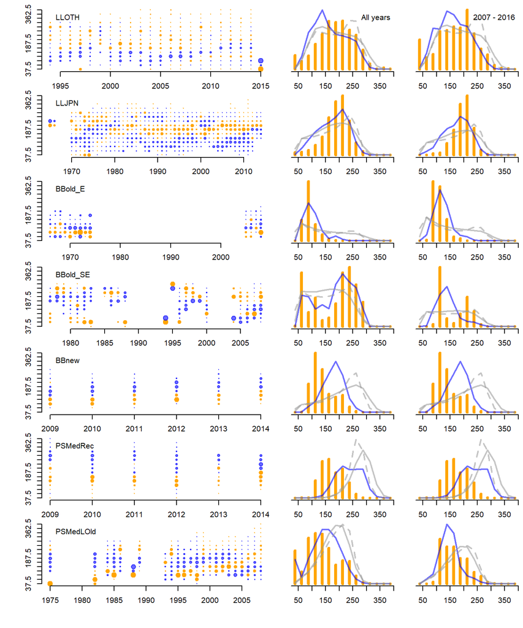

Figure 11.Length composition residuals. The left-hand panels show residuals over time. Orange circles are positive residuals (observed proportion is higher than expected), blue circles are negative residuals. The area of the circle is proportional to the absolute residuals error (i.e. if the observed proportion of a length class is 0.5 and the model predicted fraction is 0.4, this is represented by a circle ten time larger than if the observed proportion was 0.05 and the predicted fraction is 0.04). This keeps the scaling of the left-hand plots the same as the right-hand plots that show the aggregate residual error over all years and (right mosts panels) the period since 2007. Given the estimated selectivity of each fleet, the grey lines show the predicted composition of catches for a hypothetical unfished Eastern stock (solid grey line) and a hypothetical unfished western stock (dashed grey line).

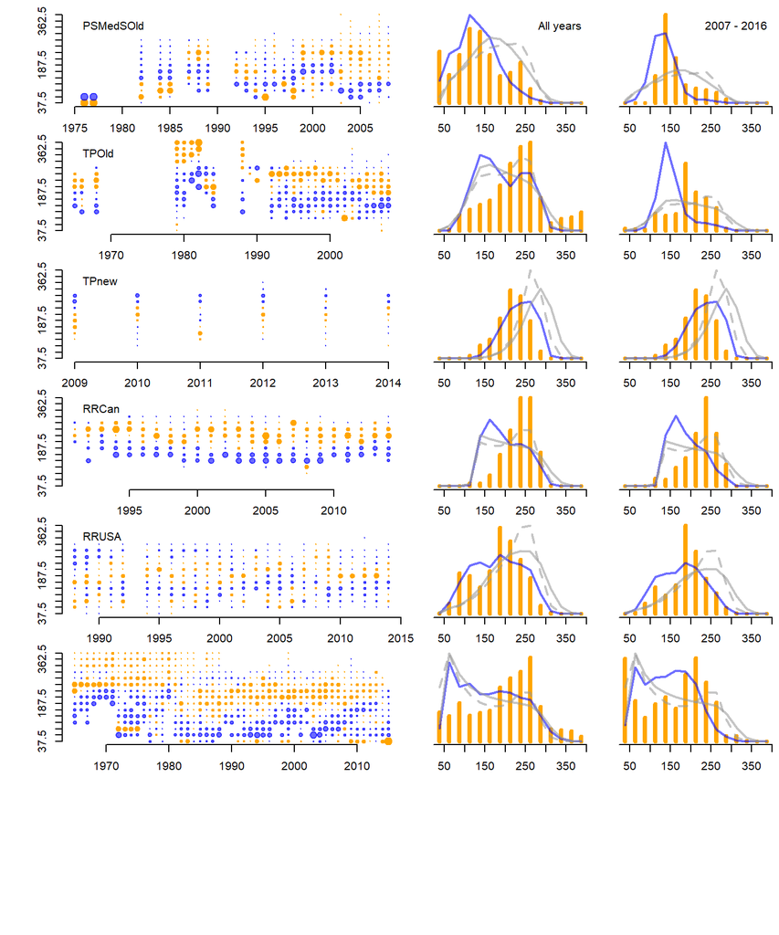

Figure 11 cont. Length composition residuals.

# 13 Spatial distribution

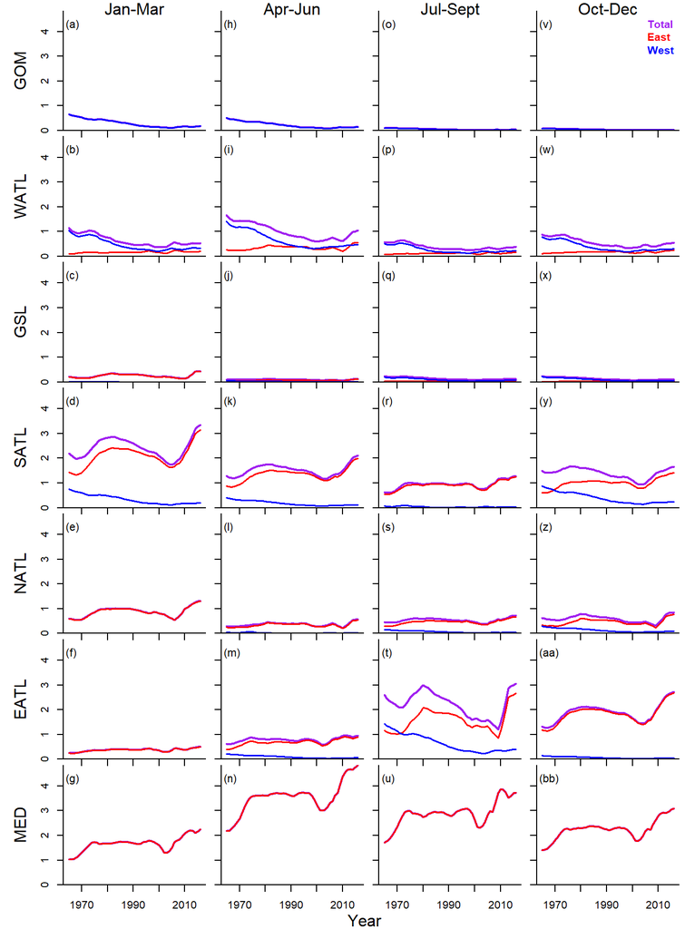

Figure 12. The predicted seasonal and spatial biomass of Atlantic bluefin tuna by stock.

# 14 Estimated unfished movement

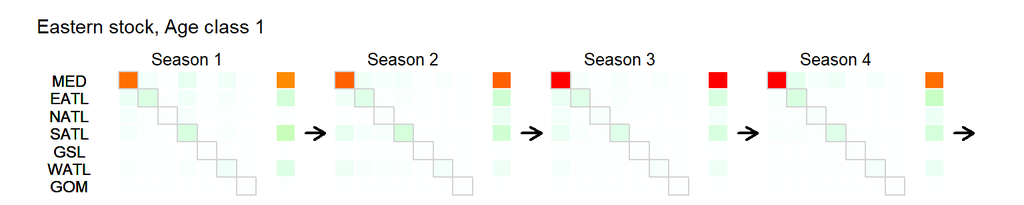

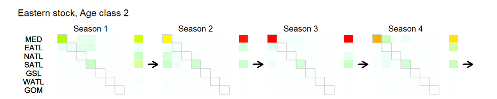

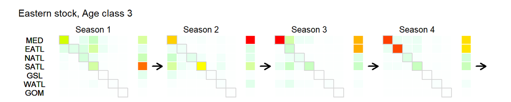

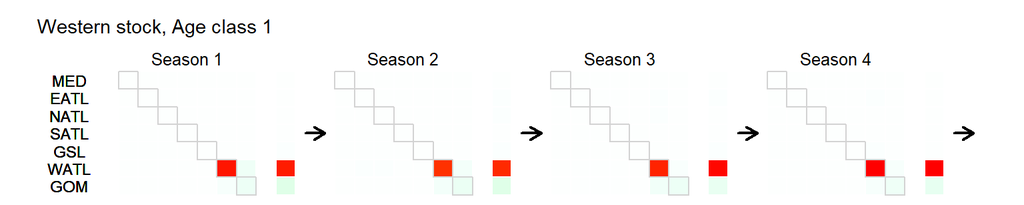

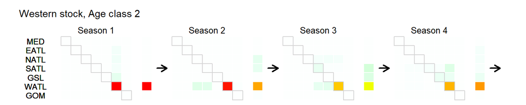

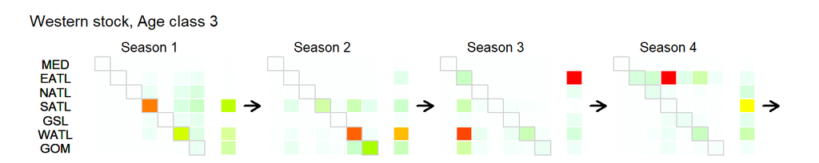

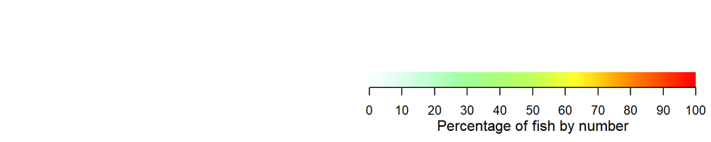

Figure 13. The movement and distribution of fish under unfished conditions. The square matrices show the fraction of fish moving from an area (rows) to an area (columns). These rows sum to 100% of fish and are color coded according to the fraction going to each area (column). The vertical bars after each square matrix is the ending distribution of fish (the new ‘from area’ by row) after this movement has occured.

# 15 Fit to stock-of-origin data

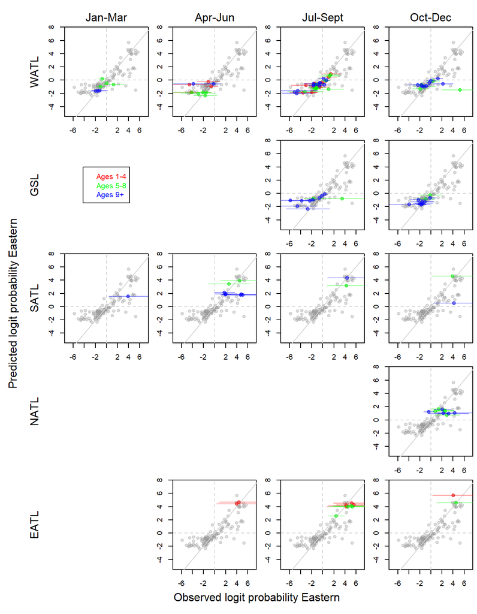

Figure 14a. The model fit to the observed probability eastern stock-of-origin data derived from otolith microchemistry data. These data were calculated by the mixture modelling approach of Carruthers and Butterworth (2018) where the ‘signature’ of Western (GOM) and Eastern (Med) assignment data are used to derive an estimate of the stock composition of fish for a given age class, in a given year, area and season. This interpretation of the assignment data provides a measure of uncertainty in probability eastern estimates. The horizontal lines represent the 90% confidence interval for the observed data. Since we present maximum likelihood estimates of the model predictions, there is a single model prediction (y-axis). Grey points represent all ofhte stock-or-origin data and are the same in each plot. The colored points and bars are specific to each panel. Green-red-blue colors represent age classes.

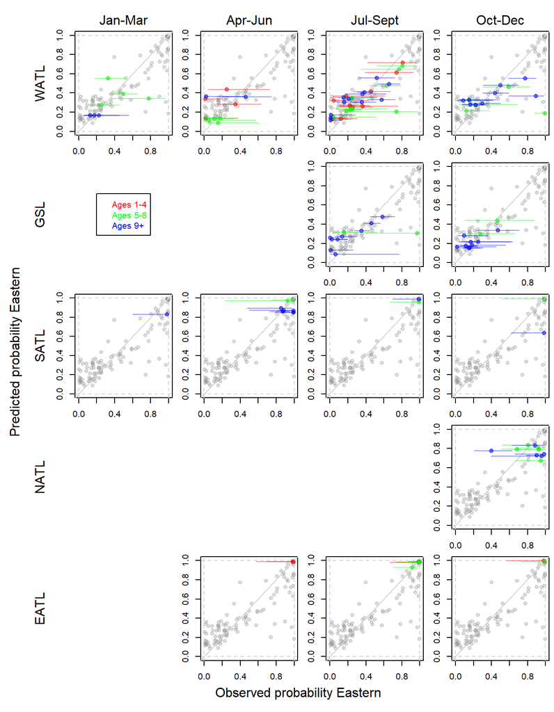

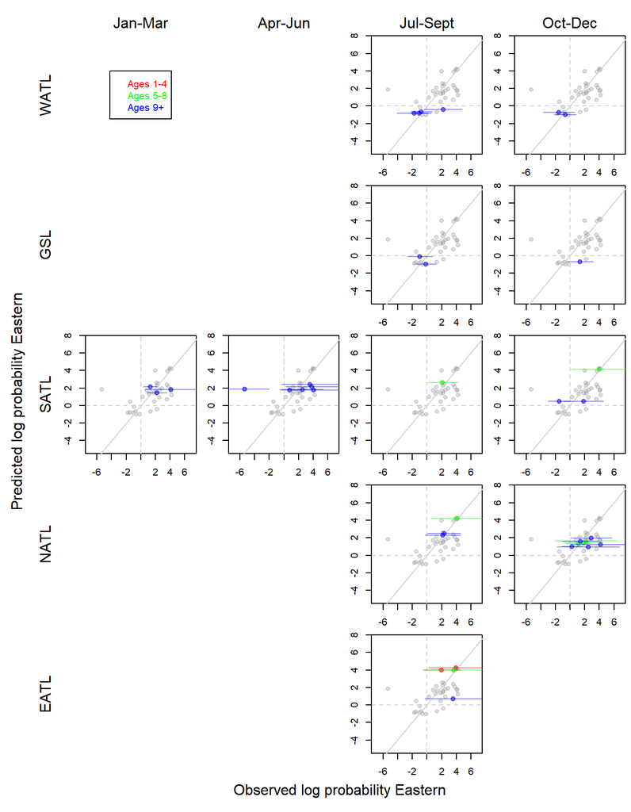

Figure 14c. As figure 14a but for the genetics stock-of-origin data.

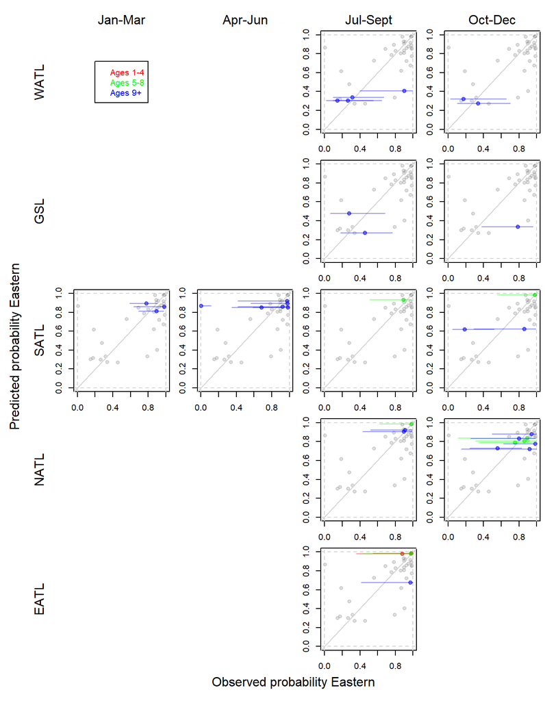

Figure 14d. As figure 14b but for the genetics stock-of-origin data.

# 16 Fit to E-tag transitions

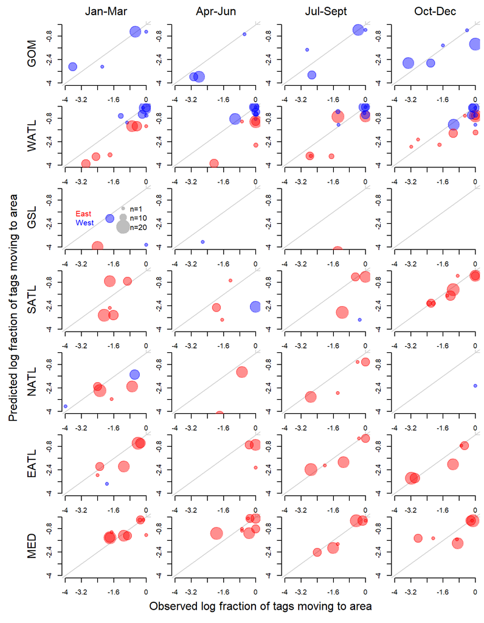

Figure 15a. The model fit to the observed log fractions of tags moving to the various areas by season. Red / blue points represent observed fraction of fish moving to an area of known eastern / western origin, respectively. The size of the bubble represents the number of tags moving. Although these plots summarize tagging transition data by area and season, these data are in fact disaggregated into strata by: area moving from (7 areas), area moving to (7 areas), season (4 quarters) and age class (3 age classes).

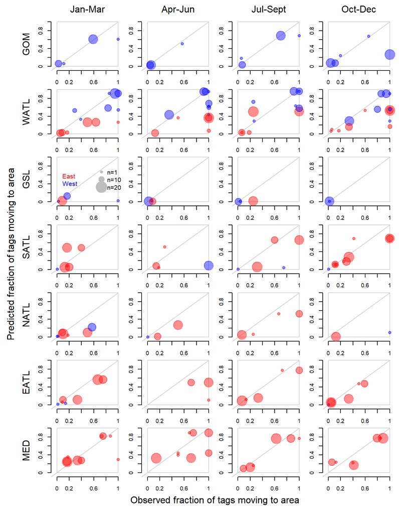

Figure 15b. As Figure 15a but showing real fractions (not log transformed)